```python
import os
import numpy as np
import pandas as pd

# Matplotlib 中文設定
import matplotlib
#matplotlib.use('TkAgg')
from matplotlib.font_manager import *
import matplotlib.pyplot as plt
plt.rcParams['font.sans-serif'] = ['Microsoft JhengHei']
plt.rcParams['font.family'] = 'sans-serif'
plt.rcParams['axes.unicode_minus'] = False

# Seaborn 尺寸、顏色
sns.set_color_codes("pastel")
sns.set(rc={'figure.figsize':(12,8)})
# Seaborn 中文設定
import seaborn as sns
sns.set(font=['sans-serif'])
sns.set_style("darkgrid",{"font.sans-serif":['Microsoft JhengHei']})
```

# Set working directory and load files

```python
os.chdir('/Users/ryanhuang/Desktop/107-2/statistical learning/Assignments/Assign4')
stu_adm = pd.read_csv('ds/student_admission106.csv', encoding="utf-8", dtype=str)
uname = pd.read_csv('ds/univ_name106short1.csv', encoding="utf-8", dtype=str)
```

# Question 1 [Data Preparation]

```python
# Make a matrix of student_ID and dep_ID
stu_dep = pd.pivot_table(
    data=stu_adm.loc[:,['department_id','student_id']],
    index='department_id',
    columns='student_id',
    fill_value=0,
    aggfunc=len)

# Select the depart with stu > 10 and stu with > 1 depart.
i = 0
while stu_dep.shape != stu_dep.loc[stu_dep.sum(1) > 10, stu_dep.sum(0) > 1].shape:
    stu_dep = stu_dep.loc[stu_dep.sum(1) > 10, stu_dep.sum(0) > 1]
#     i += 1
#     print(i)
```

Report the top ten departments that recieved the most applications and the number of applications they received. Identify the department by their department_id and names.

```python
# add applications_received column
stu_dep['applications_received'] = stu_dep.sum(1)
# sort by applications_received
top10_dep = stu_dep.sort_values(by='applications_received', ascending=False).iloc[0:10,-1].reset_index()
# join the dep_name on dep_id
top10_dep = top10_dep.merge(uname.iloc[:,[2,4,-2]], how='inner', on='department_id').iloc[:,[0,-1,-2,1]]
top10_dep
```

|  | department_id | school_name_abbr | department_name | applications_received |
| --- | --- | --- | --- | --- |
| 0 | 008122 | 中原 | 機械工程學系 | 386 |
| 1 | 012052 | 中醫 | 藥學系 | 376 |
| 2 | 046032 | 銘傳 | 會計學系（臺北校區） | 367 |
| 3 | 004382 | 成大 | 電機工程學系 | 357 |
| 4 | 005192 | 東吳 | 企業管理學系 | 353 |
| 5 | 008112 | 中原 | 土木工程學系 | 353 |
| 6 | 005182 | 東吳 | 會計學系 | 351 |
| 7 | 015342 | 逢甲 | 財務金融學系 | 340 |
| 8 | 045012 | 義守 | 電機工程學系 | 339 |
| 9 | 015222 | 逢甲 | 資訊工程學系 | 329 |

# Question 2 [Explore]

Color data points according the academic department's category and provide a legend or a picture that illustrate the mapping between colors and category names

```python
dep_category_map = stu_dep\
    .merge(uname.loc[:,['department_id','category_name']], how='inner', on='department_id')\
    .rename(columns={'category_name':'dep_category'})\
    .reset_index()\
    .loc[:,['department_id','dep_category']]
X = stu_dep.iloc[:,:-2]
```

Q2.1 Visualize academic departments using the first 8 principle components.

```python
from sklearn.decomposition import PCA
pca = PCA(n_components=8)
pca.fit(X)
X_pca = pca.transform(X)
q2_1 = pd.concat([pd.DataFrame(X_pca), dep_category_map.iloc[:,1]], axis=1)
```

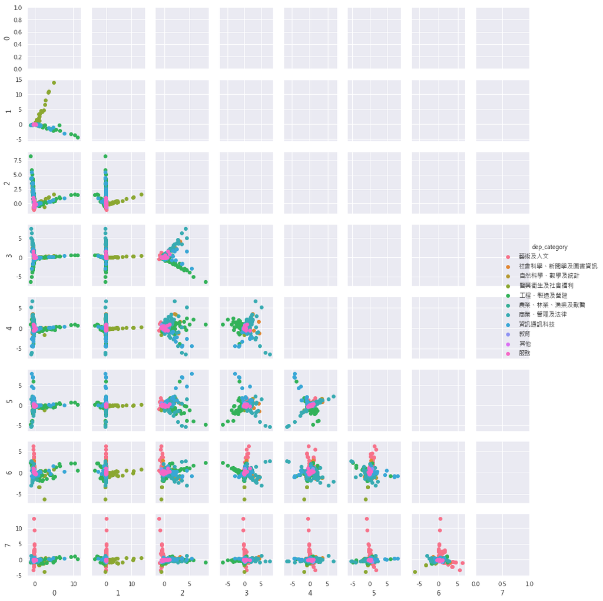

```python
g = sns.PairGrid(q2_1, hue='dep_category')
g.map_lower(plt.scatter)
g.add_legend()
g.fig.set_size_inches(15,15)
```

Q2.2 Visualize academic department using multiple dimensional scaling. Consdier both the metric and non-metric settings. Discuss the result.

```python
from sklearn.manifold import MDS

# Metric
metric_MDS = MDS()
X_M_MDS = metric_MDS.fit_transform(X)
```

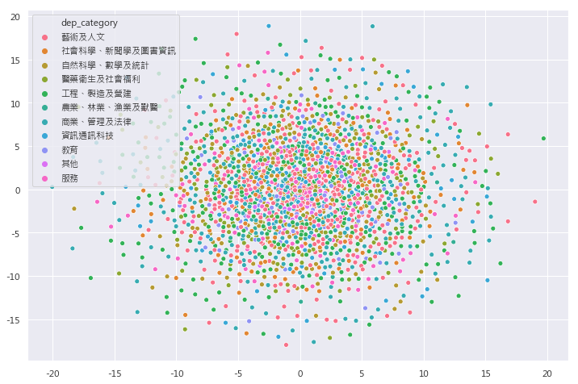

```python
sns.scatterplot(x=X_M_MDS[:,0],
                y=X_M_MDS[:,1],
                hue=dep_category_map.iloc[:,1])
```

```python
# Non-metric
nonmetric_MDS = MDS(metric=False)
X_NM_MDS = nonmetric_MDS.fit_transform(X)
```

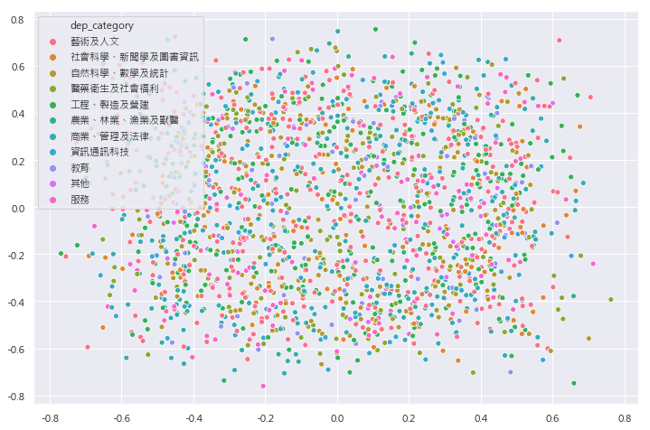

```python
sns.scatterplot(x=X_NM_MDS[:,0],
                y=X_NM_MDS[:,1],
                hue=dep_category_map.iloc[:,1])
```

```python
from sklearn.manifold import LocallyLinearEmbedding
# 20 neighbor
lle_20 = LocallyLinearEmbedding(n_components=2,n_neighbors=20)
X_reduced_20 = lle_20.fit_transform(X)
```

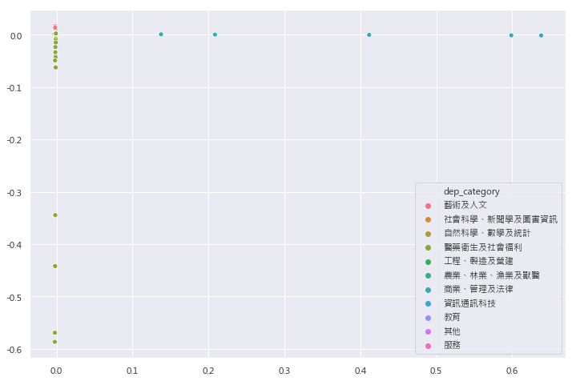

```python
sns.scatterplot(x=X_reduced_20[:,0],
                y=X_reduced_20[:,1],
                hue=dep_category_map.iloc[:,1])
```

```python
# 40 neighbor
lle_40 = LocallyLinearEmbedding(n_components=2,n_neighbors=40)
X_reduced_40 = lle_40.fit_transform(X)
```

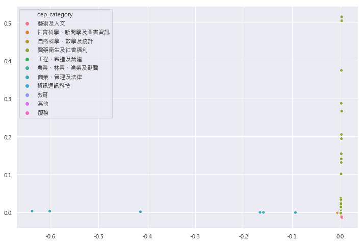

```python
sns.scatterplot(x=X_reduced_40[:,0],
                y=X_reduced_40[:,1],
                hue=dep_category_map.iloc[:,1])
```

```python
# 100 PCA + 20 neighbors
pca_20 = PCA(n_components=100)
pca_20.fit(X)
X_pca_20 = pca_20.transform(X)

lle_pca = LocallyLinearEmbedding(n_components=2, n_neighbors=20)
X_pca_reduced_20 = lle_pca.fit_transform(X)
```

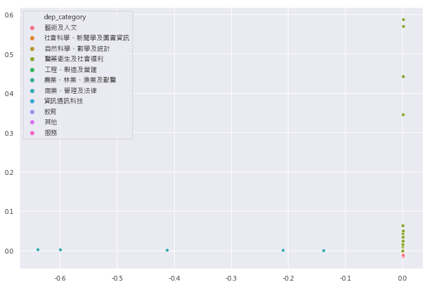

```python
sns.scatterplot(x=X_pca_reduced_20[:,0],
                y=X_pca_reduced_20[:,1],
                hue=dep_category_map.iloc[:,1])
```

Q2.4: Visualize academic department using Kernel PCA. You should at least consider the RBF and Cosine kernel. Select reasonably good kernel parameters. Discuss the result.

```python
from sklearn.decomposition import KernelPCA
from sklearn.model_selection import GridSearchCV
from sklearn.metrics import mean_squared_error
```

```python
# scorer for grid search
def my_scorer(estimator, X, y=None):
    X_reduced = estimator.transform(X)
    X_preimage = estimator.inverse_transform(X_reduced)
    return -1 * mean_squared_error(X, X_preimage)
```

```python
param_grid = [{
        "gamma": np.linspace(1/X.shape[1], 0.005, 5),
        "kernel": ["rbf", "cosine"]
    }]
```

```python
tuned_kpca = KernelPCA(fit_inverse_transform=True, n_jobs=-1)
grid_search = GridSearchCV(tuned_kpca, param_grid, cv=3, scoring=my_scorer)
grid_search.fit(stu_dep.iloc[:,:-2])
```

```
GridSearchCV(cv=3, error_score='raise-deprecating',
       estimator=KernelPCA(alpha=1.0, coef0=1, copy_X=True, degree=3, eigen_solver='auto',
     fit_inverse_transform=True, gamma=None, kernel='linear',
     kernel_params=None, max_iter=None, n_components=None, n_jobs=-1,
     random_state=None, remove_zero_eig=False, tol=0),
       fit_params=None, iid='warn', n_jobs=None,
       param_grid=[{'gamma': array([2.11082e-05, 1.26583e-03, 2.51055e-03, 3.75528e-03, 5.00000e-03]), 'kernel': ['rbf', 'cosine']}],
       pre_dispatch='2*n_jobs', refit=True, return_train_score='warn',
       scoring=<function my_scorer at 0x1a17e137b8>, verbose=0)
```

```python
best_pa = grid_search.best_params_
tuned_kpca = KernelPCA(kernel=best_pa['kernel'], n_components=2, gamma=best_pa['gamma'])
X_tuned_kpca = tuned_kpca.fit_transform(stu_dep.iloc[:,:-2])
```

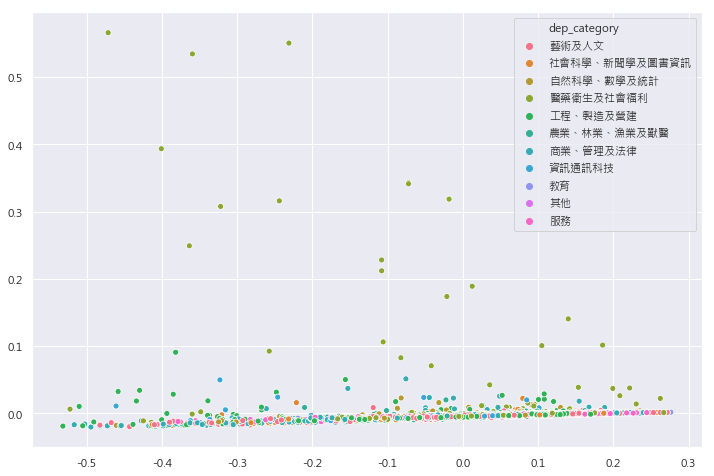

```python
sns.scatterplot(x=X_tuned_kpca[:,0],
                y=X_tuned_kpca[:,1],
                hue=dep_category_map.iloc[:,1])
```

Q2.5: Visualize academic department using t-SNE. Consider at least the Euclidian, Cosine, and Jaccard metric. Set numpy random seed so that your results can be repeated. Discuss the result.

```python
from sklearn.manifold import TSNE

# Euclidian
tsne_Euclidian = TSNE(n_components=2, init='random', random_state=0, metric='euclidean')
X_tsne_Euclidian = tsne_Euclidian.fit_transform(X)
```

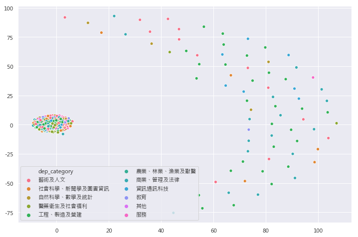

```python
sns.scatterplot(x=X_tsne_Euclidian[:,0],
                y=X_tsne_Euclidian[:,1],
                hue=dep_category_map.iloc[:,1])
plt.legend(loc='lower left',ncol=2)
```

```python
# Cosine
tsne_Cosine = TSNE(n_components=2, init='random', random_state=0, metric='cosine')
X_tsne_Cosine = tsne_Cosine.fit_transform(X)
```

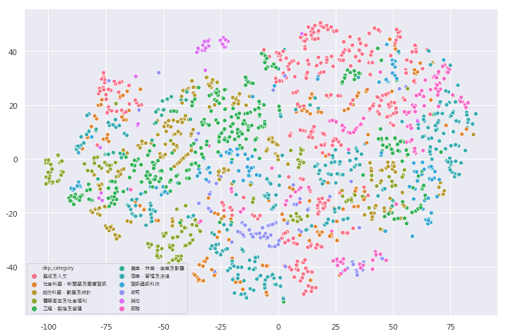

```python
sns.scatterplot(x=X_tsne_Cosine[:,0],
                y=X_tsne_Cosine[:,1],
                hue=dep_category_map.iloc[:,1])
plt.legend(loc='lower left',ncol=2, fontsize=7)
```

```python
# Jaccard
tsne_Jaccard = TSNE(n_components=2, init='random', random_state=0, metric='jaccard')
X_tsne_Jaccard = tsne_Jaccard.fit_transform(X)
```

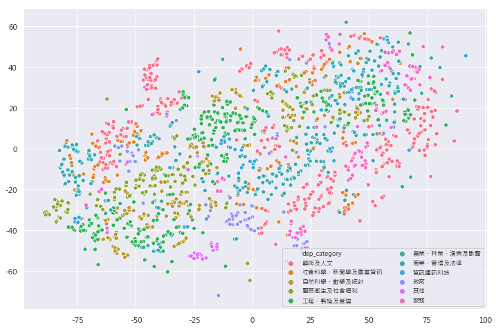

```python
sns.set(rc={'figure.figsize':(12,8)})
sns.set(font=['sans-serif'])
sns.set_style("darkgrid",{"font.sans-serif":['Microsoft JhengHei']})
sns.set_color_codes("pastel")
sns.scatterplot(x=X_tsne_Jaccard[:,0],
                y=X_tsne_Jaccard[:,1],
                hue=dep_category_map.iloc[:,1])
plt.legend(loc='lower right',ncol=2, fontsize=9)
```

# Question 3 [Refine]

Select the most promising visualization method in the previous question and refine the result. Your should color points by department category. Label each data point with its name so that we can easily identify a data point on the picture.

```python
# Seaborn 尺寸、顏色
sns.set_color_codes("pastel")
sns.set(rc={'figure.figsize':(120,90)})
# Seaborn 中文設定
import seaborn as sns
sns.set(font=['sans-serif'])
sns.set_style("darkgrid",{"font.sans-serif":['Microsoft JhengHei']})

# prepare output text
uname['output'] = uname['school_name_abbr'] + uname['department_name_abbr']
output = dep_category_map.merge(uname.loc[:,['department_id','output']],
                       on='department_id', how='inner')

final_plot = sns.scatterplot(x=X_tsne_Jaccard[:,0],
                             y=X_tsne_Jaccard[:,1],
                             hue=dep_category_map.iloc[:,1],
                             y_jitter=True)

for line in range(0,X_tsne_Jaccard.shape[0]):
     final_plot.text(X_tsne_Jaccard[line,0]+0.2,
                     X_tsne_Jaccard[line,1],
                     output.iloc[line,-1],
                     horizontalalignment='left',
                     fontsize=10,
                     color='gray', weight='semibold')
plt.savefig('output.png')
plt.close()
```